# MTMM.00.195 Sissejuhatus finantsmatemaatikasse

# Monte Carlo meetodid

## Priit Lätt

### 24.11.14

Impordime vajalikud tööriistad, mida edasises kasutama hakkame.

```python
import matplotlib.pyplot as plt
import numpy as np

from IPython.display import Math

import sys

if sys.version_info.major == 2:
    range = xrange

random = np.random.rand
```

# Meetodi kirjeldus

#### **Monte Carlo meetod** on statistikal põhinev probleemide lahendamise meetod.

- Kui meil on ette antud mingi tõenäosus $P$, mis näitab mingitel tingimustel vea esinemist, on arvutite abil võimalik selliseid tingimusi korduvalt genereerida.
- Sündmuse esinemiste arvu jagamisel tingumuste genereerimise arvuga, peaksime saama ligikaudu tõenäosuse $P$.

Seda mõttekäiku kasutades on võimalik arvutada erinevaid väärtusi.

# $\pi$ väärtuse arvutamine

Kui meil on ring raadiusega $R$ sisestatud ruutu küljepikkusega $2R$, siis

- ringi pindala on $S_{ring} = \pi R^2$
- ruudu pindala on $S_{ruut} = 4R^2$.

Niisiis ringi ja ruudu pindalad suhtuvad teineteisse kujul

$$ \frac{S_{ring}}{S_{ruut}} = \frac{\pi}{4} $$

Teisi sõnu, kui me valime $N$ punkti ruudu seest, peaks umbes

$$ \frac{N\pi}{4} $$

neist punktidest langema ringi sisse.

Olgu ringi raadius $R$.

- valime juhuslikult ruudu seest mingi punkti $(x, y)$
- kontrollime kas punkt $(x, y)$ asub ka ringis, see tähendab, kas $x^2 + y^2 < R^2$
- jätame meelde genereeritud punktide arvu $N$
- ja ringi sisse sattnud punktide arvu $M$

$\pi$ saab siis ligikaudu arvutada kujul:

$$ \pi \approx \frac{4M}{N} $$

Defineerime konstandi `PI` väärtuseks $3.14159265359$.

```python
PI = 3.14159265359
```

```python
def approximate_pi(times):
    in_x, in_y, out_x, out_y = [], [], [], []
    for _ in range(times):
        x, y = random(), random()
        if  np.hypot(x, y) < 1:
            in_x.append(x)
            in_y.append(y)
        else:
            out_x.append(x)
            out_y.append(y)
    return in_x, in_y, out_x, out_y
```

```python
x = np.arange(0, 1, 0.01)

times = (10, 100, 500, 1000, 5000, 10000, 20000, 50000)
rows = int(len(times)/4) + len(times) % 4
columns = 4
```

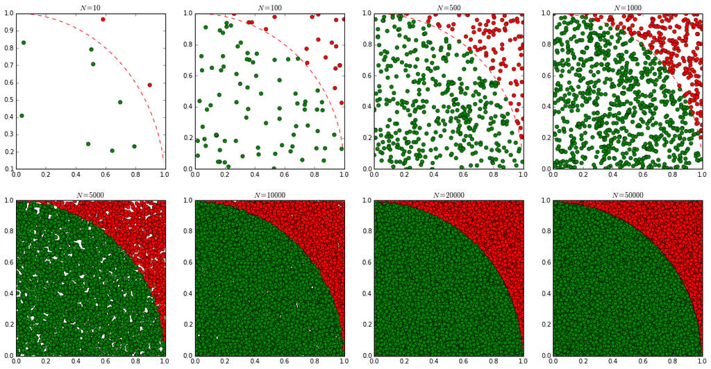

```python
plt.figure(figsize=(20, rows*5))
plt.rcParams['font.size'] = 10

results = []

for i, N in enumerate(times):
    in_x, in_y, out_x, out_y = approximate_pi(N)
    plt.subplot(rows, columns, i+1)
    plt.plot(in_x, in_y, 'go')
    plt.plot(out_x, out_y, 'ro')
    plt.plot(x, np.sqrt(1 - x**2), 'r--')
    plt.title(r"$N = %d$" % N)

    pi = 4.0*len(in_x) / N
    results.append((N, pi))
```

```python
for N, pi in results:
    print "n = %d: pi = %f (viga: %f)" % (N, pi, np.abs(PI-pi))
```

```
n = 10: pi = 3.200000 (viga: 0.058407)
n = 100: pi = 3.200000 (viga: 0.058407)
n = 500: pi = 3.256000 (viga: 0.114407)
n = 1000: pi = 3.132000 (viga: 0.009593)
n = 5000: pi = 3.152800 (viga: 0.011207)
n = 10000: pi = 3.150400 (viga: 0.008807)
n = 20000: pi = 3.131600 (viga: 0.009993)
n = 50000: pi = 3.149200 (viga: 0.007607)
```

### Monte Carlo meetodite omadusi

- Sageli kasulik lahendamaks probleeme rakendusmatemaatikast või füüsikast;
- mõistlik kui probleemi ei saa analüütiliselt lahendada;
- üldiselt aeglane ja ebaefektiivne viis.

Viimast illustreeris ka $\pi$ arvutamine.

Defineerime eelnevaga analoogilise, kuid mõnevõrra efektiivsema funktsiooni $\pi$ ligikaudse väärtuse leidmiseks.

```python
def approximate_pi_2(N):
    M = 0
    for _ in range(N):
        if  np.hypot(random(), random()) < 1:
            M += 1
    return 4.0*M / N
```

```python
for N in (10, 100, 1000, 10000, 100000, 1000000, 10000000):
    print "\nN = %d" % N
    pi_1, pi_2 = approximate_pi_2(N), approximate_pi_2(N)
    print "pi = %.16f (viga %.16f)" % (pi_1, np.abs(PI-pi_1))
    print "pi = %.16f (viga %.16f)" % (pi_2, np.abs(PI-pi_2))
```

```
N = 10
pi = 3.2000000000000002 (viga 0.0584073464100001)
pi = 3.6000000000000001 (viga 0.4584073464100000)

N = 100
pi = 3.1200000000000001 (viga 0.0215926535900000)
pi = 3.1200000000000001 (viga 0.0215926535900000)

N = 1000
pi = 3.1360000000000001 (viga 0.0055926535899999)
pi = 3.0920000000000001 (viga 0.0495926535900000)

N = 10000
pi = 3.1396000000000002 (viga 0.0019926535899999)
pi = 3.1128000000000000 (viga 0.0287926535900001)

N = 100000
pi = 3.1440000000000001 (viga 0.0024073464100001)
pi = 3.1358400000000000 (viga 0.0057526535900001)

N = 1000000
pi = 3.1421440000000000 (viga 0.0005513464100000)
pi = 3.1414279999999999 (viga 0.0001646535900002)

N = 10000000
pi = 3.1417212000000001 (viga 0.0001285464100000)
pi = 3.1414955999999998 (viga 0.0000970535900002)
```

Uurime arvutuste käigus tekkivaid vigu.

```
Vigade keskväärtus: 0.0134331754256
Minimaalne viga: 7.34640999989e-06
Maksimaalne viga: 0.04280734641
```

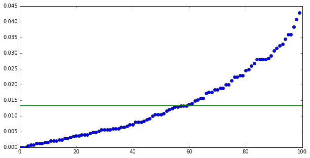

```python
errors = np.array([np.abs(approximate_pi_2(10000) - PI) for _ in range(100)])
mean = errors.mean()
print "Vigade keskväärtus:", mean
print "Minimaalne viga:", errors.min()
print "Maksimaalne viga:", errors.max()

plt.figure(figsize=(10, 5))
plt.plot(sorted(errors), 'o')
plt.plot((0, 100), (mean, mean))
plt.show()
```

# Määratud integraalide ligikaudne arvutamine

Määratud integraali leidmine tähendab integreeritava joone ja $x$-telje poolt määratud pinnatüki pindala leidmist.

[figure not shown]

### Ühe muutuja funktsioonide integreerimine

Vaatleme vahemikus $(a, b)$ integreeruvat funktsiooni $f \colon X \rightarrow \mathbb{R}$, kus $X \subset \mathbb{R}$. Kui $x_1, \dots, x_N$ ühtlaselt jaotatud juhuslikud arvud vahemikust $(a, b)$, siis

$$ S = \frac{b - a}{n} \sum_{i=1}^{N} f(x_i) $$

on ligikaudne väärtus integraalile

$$ \int_a^b f(x)\ \mathrm{d}x. $$

Sellist meetodit kutsutakse tavaliselt **Monte Carlo integreerimiseks**.

```python
def integrate(func, a, b, N=1000):
    r = a + (b - a)*random(N)
    s = np.sum(func(r))
    return s*(b-a)/N
```

$$\int_{0}^{\pi} \sin(x)\ \mathrm{d}x \approx 2.0596752377781278$$

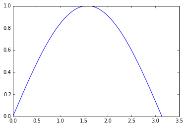

```python
x = np.arange(0, np.pi, 0.01)
plt.plot(x, np.sin(x))

Math(r'\int_{0}^{\pi} \sin(x)\ \mathrm{d}x \approx %.16f' % integrate(np.sin, 0.0, np.pi))
```

$$\int_{0}^{\pi} \cos(x)\ \mathrm{d}x \approx -0.0214117202703899$$

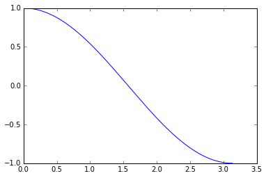

```python
x = np.arange(0, np.pi, 0.01)
plt.plot(x, np.cos(x))

Math(r'\int_{0}^{\pi} \cos(x)\ \mathrm{d}x \approx %.16f' % integrate(np.cos, 0.0, np.pi))
```

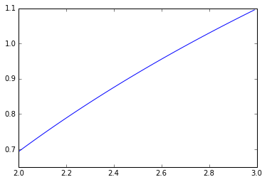

```python
x = np.arange(2, 3, 0.01)
plt.plot(x, np.log(x))

Math(r'\int_{-1}^{1} \ln x\ \mathrm{d}x \approx %.16f' % integrate(np.log, 2.0, 3.0))
```

[output not shown]

$$\int_{-1}^{1} e^x\ \mathrm{d}x \approx 2.3855159229793688$$

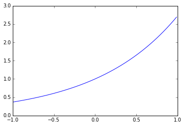

```python
x = np.arange(-1, 1, 0.01)
plt.plot(x, np.exp(x))

Math(r'\int_{-1}^{1} e^x\ \mathrm{d}x \approx %.16f' % integrate(np.exp, -1, 1))
```

### Mitme muutuja funktsioonide integreerimine

Vaatleme piirkonnas $\Omega$ integreeruvat funktsiooni $f \colon X \rightarrow \mathbb{R}$, kus $X \subset \mathbb{R}^m$.

Meie eesmärgiks on arvutada $m$-muutuja integraali

$$ \int_\Omega f(x_1, \dots, x_n)\ \mathrm{d}x_1 \dots \mathrm{d}x_m $$

väärtus.

Idee on vaadelda piirkonda $\Omega$ kastis

$$ B = [\alpha_1, \beta_1] \times \dots \times [\alpha_m, \beta_m], $$

kus $\Omega \subset B$. Defineerime hulgal $B$ uue funktsiooni $F$ järgmiselt:

$$ F(x_1, \dots, x_m) = \begin{cases} f(x_1, \dots, x_m) & \text{ kui } (x_1, \dots, x_m) \in \Omega, \\ 0 & \text{ muudel juhtudel}. \end{cases} $$

Siis saame integraali

$$ \int_\Omega f(x_1, \dots, x_n)\ \mathrm{d}x_1 \dots \mathrm{d}x_m $$

arvutada ligikaudselt järgmiselt:

$$ \int_\Omega f(x_1, \dots, x_n)\ \mathrm{d}x_1 \dots \mathrm{d}x_m \approx \frac{V}{N} \sum_{i=1}^{N} F(x_1^{(i)}, \dots, x_m^{(i)}), $$

kus $V$ tähistab kasti $B$ ruumala ning $x_1^{(i)}, \dots, x_m^{(i)}$ on $i = 1, \dots, n$ ja $j = 1, \dots, m$ jaoks sõltumatud ühtlaselt jaotatud juhuslikud arvud.

Seda arutelu realiseerib järgmine funktsioon.

```python
def mc_integrate(func, omega, B, N=100000):
    rs = np.array([a + (b - a)*random(N) for a, b in B])
    s = 0
    for i in range(N):
        r = rs[:,i]
        if omega(r):
            s += func(r)
    V = np.prod([b-a for a, b in B])
    return V*s/N
```

```python
omega = lambda x: True
f = lambda x: x[0]*x[1]**2
B = np.array([[0, 2], [0, 1]])

Math(r'\iint_{\Omega} y^2\ \mathrm{d}x \mathrm{d}y \approx %.16f' %
     mc_integrate(f, omega, B))
```

[output not shown]

$$\iint_{\Omega} y^2\ \mathrm{d}x \mathrm{d}y \approx 9.9331887734456554$$

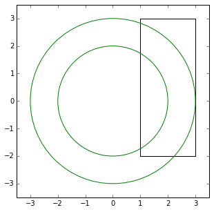

```python
fig = plt.figure(figsize=(5, 5))
axes = fig.gca()
axes.add_artist(plt.Circle((0,0), 3, color='g', fill=False))
axes.add_artist(plt.Circle((0,0), 2, color='g', fill=False))
axes.add_patch(Rectangle((1, -2), 2, 5, facecolor="white"))
axes.set_xlim([-3.5, 3.5])
axes.set_ylim([-3.5, 3.5])

omega = lambda x: 2 <= np.sqrt(x[0]**2 + x[1]**2) <= 3
f = lambda x: x[1]**2

B = np.array([[1, 3], [-2, 3]])

Math(r'\iint_{\Omega} y^2\ \mathrm{d}x \mathrm{d}y \approx %.16f' %
     mc_integrate(f, omega, B))
```